# Climate Change

Dr. Ahmad Redaa

2025-01-29

# **Weather vs. Climate**

### **Weather**

- Short-term atmospheric conditions (e.g., daily temperature, rainfall).
- Varies significantly from day to day.

### **Climate**

- Long-term average of weather patterns over decades or centuries.
- Determines the general environmental conditions of a region.

**Key Difference:** Weather is what you experience daily; climate is the long-term trend.

# Weathering and Climate Change

### **Impact of Climate Change on Weathering**

- Extreme Weather Events: More frequent and intense storms can increase erosion rates, particularly in areas prone to landslides or flash floods. This can lead to the rapid removal of soil and rock materials.
- Carbon Sequestration: Weathering of silicate minerals plays a crucial role in the long-term carbon cycle. As rocks weather, they react with carbon dioxide (CO₂) from the atmosphere, forming carbonate minerals and effectively removing CO₂ from the atmosphere.
- Soil Formation and Vegetation: Weathering contributes to soil formation, which supports vegetation. Healthy ecosystems can sequester carbon, further influencing atmospheric CO₂ levels.
- Deforestation and soil degradation, often exacerbated by climate change, can reduce the ability of soils to store carbon.

# **What is Climate Change?**

- **Definition:**  
  Climate change refers to long-term changes in global or regional climate patterns, often attributed to human activities since the Industrial Revolution.
- **Key Driver:**  
  Increase in greenhouse gas concentrations leading to global warming.

# **Greenhouse Gases and Their Role**

### **1. Carbon Dioxide (CO₂)**

- Emitted through burning fossil fuels, deforestation, and industrial processes.
- Most significant long-lived greenhouse gas.

### **2. Methane (CH₄)**

- Released from agriculture (e.g., rice paddies, livestock digestion), landfills, and fossil fuel production.
- More effective at trapping heat than CO₂ but exists in smaller quantities.

### **3. Nitrous Oxide (N₂O)**

- Emitted from fertilizer use, industrial activities, and combustion.

### **4. Fluorinated Gases**

- Synthetic gases from industrial applications (e.g., refrigerants).
- Potent heat trappers despite lower quantities.

# **Historical Global Temperature Fluctuations**

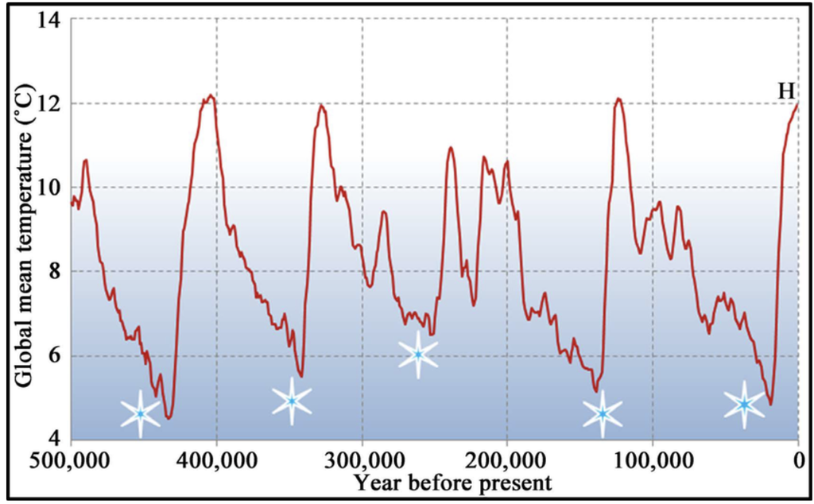

Source: [Adamo, et al. (2021)](https://www.researchgate.net/figure/Global-mean-temperatures-over-the-last-500-000-years-11_fig3_356606430)

### Possible Causes:

1. **Milankovitch Cycles:** Orbital changes influence Earth’s climate over thousands of years.
- Variations in Earth’s orbit and tilt affect the amount and distribution of solar energy received by the planet. The three main cycles are:
  - Eccentricity (100,000-year cycle): Changes in the shape of Earth’s orbit around the Sun, from more circular to more elliptical. When the orbit is more elliptical, the difference in solar energy between seasons increases, influencing glacial and interglacial periods.
  - Axial Tilt (Obliquity) (41,000-year cycle): Changes in the tilt of Earth’s axis. A higher tilt angle increases the difference in solar energy between summer and winter, promoting warmer interglacial periods.
  - Precession (23,000-year cycle): The wobble in Earth’s axis affects the timing of the seasons relative to Earth’s position in its orbit, influencing the intensity of seasons.
2. **Ocean Currents:** Disruptions alter heat distribution globally.
3. **Volcanic Activity and Plate Tectonics:** Over geological timescales, volcanic eruptions can release CO₂ into the atmosphere. Similarly, changes in plate tectonics can alter ocean currents and atmospheric CO₂ levels, contributing to natural warming events. In addition, eruptions release particles that can cool the atmosphere temporarily.
4. **Solar Variability:** Minor fluctuations in solar radiation can also influence Earth’s climate, although this is less significant compared to orbital changes over these timescales..

# **Human Activities and Climate Change**

### **1. Burning Fossil Fuels**

- Releases massive amounts of CO₂ and other greenhouse gases for energy, heat, and transportation.

### **2. Deforestation**

- Reduces Earth’s ability to absorb CO₂, weakening the carbon sink.

### **3. Agriculture**

- Livestock production emits methane.
- Fertilizers release nitrous oxide.

### **4. Industrial Processes**

- Emissions from cement production and chemical manufacturing.

### **5. Waste Management**

- Landfills emit methane from decomposing organic waste.

# **Impacts of Increased Global Temperatures**

- **Melting Glaciers:** Contributes to rising sea levels.
- **Extreme Weather:** More frequent heatwaves, hurricanes, and droughts.
- **Disruptions in Ecosystems:** Loss of biodiversity.
- **Agricultural Impacts:** Reduced crop yields due to heat stress.
- **Human Health:** Heat-related illnesses and waterborne diseases.

# **Climate Change Impacts in Saudi Arabia**

### **1. Temperature Increases**

- Summer temperatures exceed 50°C, increasing cooling demands.

### **2. Water Scarcity**

- Declining groundwater supplies and water availability.

### **3. Agricultural Impact**

- Reduced crop yields due to heat and changing rainfall.

### **4. Desertification**

- Loss of arable land and biodiversity.

### **5. Health Risks**

- Heatwaves increase heat-related illnesses.

# **Adaptation Strategies**

- **Renewable Energy:** Investments in solar and wind energy.
- **Water Conservation:** Implementation of efficient water management systems.
- **Saudi Green Initiative:** Programs to combat desertification and promote sustainability.

# **Responding to Climate Change**

### **1. Mitigation**

- Reduce greenhouse gas emissions.
- Transition to renewable energy sources.

### **2. Adaptation**

- Build resilient infrastructure.
- Adjust agricultural practices.
- Develop social support services to respond to climate impacts.